# HNB DigiMedia Map 10: Audience Segmentation

Mapping Source Types to Audience Segments for Strategic Communication

Author

HNB DigiMedia Project

Published

January 28, 2026

# 1 Introduction

This document presents **Map 10: Audience Segmentation Analysis** of the HNB DigiMedia project. The core question driving this analysis is:

> **Do different source types reach different audiences, and what are the implications for HNB communication strategy?**

## 1.1 Theoretical Motivation

The literature establishes fundamental audience heterogeneity in central bank communication:

1. **Rational inattention (Sims):** Economic agents have finite information-processing capacity, explaining why “financial market participants attend to every nuance of central bank statements while ordinary people react sluggishly”
2. **Delphic vs Odyssean guidance (Campbell et al.):** Different audiences interpret forward guidance differently—experts distinguish between forecasting (Delphic) and commitment (Odyssean), while general audiences may conflate them
3. **Layered communication (ECB):** The ECB’s 2021 strategy review emphasized the need for “layered communication” with different messages for different audiences
4. **Public knowledge gap:** Coibion et al. found that reading FOMC statements has “about the same average effect on expectations as simply being told the Fed’s inflation target”—suggesting general audiences need simplified intermediation

## 1.2 Audience Segmentation Framework

We cannot directly observe audiences, but we can infer likely audience segments from source characteristics:

| Audience Segment | Proxy Indicators | Likely Sources |
| --- | --- | --- |
| Professional/Expert | Business hours, weekday, high technical density | Financial Media, HNB Official |
| Informed Public | Mixed timing, moderate complexity | Quality General Media |
| General Public | Evening/weekend, low complexity | Mass General Media |

```r
hnb <- readRDS("C:/Users/lsikic/Dropbox/hnb.rds")
setDT(hnb)

hnb[, date := as.Date(DATE)]
hnb[, year := year(date)]
hnb[, month := month(date)]
hnb[, DOW := lubridate::wday(date, label = TRUE, abbr = FALSE)]
hnb[, DOW_num := lubridate::wday(date)]
hnb[, is_weekend := DOW_num %in% c(1, 7)]  # Sunday = 1, Saturday = 7
hnb[, day_type := ifelse(is_weekend, "Weekend", "Weekday")]

# Extract hour if TIME is available
if ("TIME" %in% names(hnb) && sum(!is.na(hnb$TIME)) > 100) {
  hnb[, hour := as.integer(substr(TIME, 1, 2))]
  has_time <- TRUE
} else {
  hnb[, hour := NA_integer_]
  has_time <- FALSE
}

hnb[, period := fcase(
  date < as.Date("2023-01-01"), "ERM II",
  default = "Euro Era"
)]
hnb[, period := factor(period, levels = c("ERM II", "Euro Era"))]

n_articles <- nrow(hnb)
n_sources <- uniqueN(hnb$FROM)

cat("Data loaded:", n_articles, "articles from", n_sources, "sources\n")
```

```
Data loaded: 19128 articles from 894 sources
```

```r
cat("Time data available:", has_time, "\n")
```

```
Time data available: TRUE
```

```r
# =============================================================================
# ACTOR CLASSIFICATION - SYNCHRONIZED WITH MAPS 1-9
# =============================================================================

manual_overrides <- list(
  "HNB Official" = c(
    "hnb.hr", "hrvatska narodna banka",
    "hrvatska narodna banka / croatian national bank"
  ),
  "Financial Regulators" = c(
    "hanfa.hr", "hanfa", "hrvatska agencija za nadzor financijskih usluga",
    "fina.hr", "fina", "financijska agencija"
  ),
  "Government" = c(
    "gov.hr", "vlada", "vlada republike hrvatske",
    "ministarstvo financija", "sabor.hr"
  ),
  "Financial Media" = c(
    "poslovni.hr", "poslovni dnevnik", "seebiz.eu", "seebiz",
    "lider.media", "lidermedia.hr", "lider", "bloombergadria.com",
    "bloomberg adria", "hrportfolio.hr", "privredni.hr"
  ),
  "Commercial Banks" = c(
    "zaba.hr", "zagrebačka banka", "pbz.hr", "privredna banka zagreb",
    "erste.hr", "erste banka", "hpb.hr", "hrvatska poštanska banka",
    "otp banka", "raiffeisen", "addiko"
  ),
  "Academic/Expert" = c(
    "eizg.hr", "ekonomski institut zagreb", "ijf.hr",
    "institut za javne financije", "ekonomski fakultet"
  )
)

general_media_sources <- c(
  "index.hr", "index", "jutarnji.hr", "jutarnji", "jutarnji list",
  "vecernji.hr", "vecernji", "večernji list",
  "24sata.hr", "24sata", "slobodnadalmacija.hr", "slobodna dalmacija",
  "novilist.hr", "novi list", "dnevnik.hr", "dnevnik",
  "tportal.hr", "tportal", "telegram.hr", "telegram",
  "net.hr", "rtl.hr", "rtl", "hrt.hr", "hrt",
  "n1info.hr", "n1info.com", "n1", "nacional.hr", "nacional",
  "direktno.hr", "direktno", "dnevno.hr", "dnevno"
)

classify_actor_hnb <- function(from_val, url_val = NA) {
  from_lower <- tolower(trimws(as.character(from_val)))
  url_lower <- tolower(ifelse(is.na(url_val), "", as.character(url_val)))
  combined <- paste(from_lower, url_lower)

  match_any <- function(patterns, text, fixed = TRUE) {
    any(sapply(patterns, function(p) grepl(p, text, fixed = fixed)))
  }

  for (actor_type in names(manual_overrides)) {
    if (match_any(manual_overrides[[actor_type]], from_lower)) {
      return(actor_type)
    }
  }

  if (grepl("hnb\\.hr", url_lower) || grepl("hnb\\.hr", from_lower)) {
    return("HNB Official")
  }

  if (grepl("hanfa|fina\\.hr", combined)) {
    return("Financial Regulators")
  }

  if (grepl("gov\\.hr|vlada|ministarstvo", combined)) {
    return("Government")
  }

  bank_patterns <- c("banka", "bank", "zaba", "pbz", "erste", "hpb",
                     "otp", "raiffeisen", "addiko", "sberbank")
  if (match_any(bank_patterns, from_lower)) {
    if (!grepl("narodna|hnb|central", from_lower)) {
      return("Commercial Banks")
    }
  }

  financial_media_patterns <- c(
    "poslovni", "seebiz", "lider", "bloomberg", "portfolio",
    "privredni", "finance", "ekonom", "business", "capital"
  )
  if (match_any(financial_media_patterns, from_lower)) {
    return("Financial Media")
  }

  if (match_any(general_media_sources, from_lower)) {
    return("General Media")
  }

  news_patterns <- c("portal", "vijesti", "news", "info", "dnevni",
                     "radio", "tv", ".hr")
  if (match_any(news_patterns, from_lower)) {
    return("General Media")
  }

  return("Other")
}

hnb[, ACTOR_TYPE := mapply(classify_actor_hnb, FROM, URL)]
hnb[, INSTITUTIONAL := ACTOR_TYPE %in% c("HNB Official", "Financial Regulators", "Government")]
```

# 2 Analysis 10.1: Source Type Profiles

## 2.1 Actor Type Overview

```r
actor_profiles <- hnb[, .(
  Articles = .N,
  Sources = uniqueN(FROM),
  Total_REACH = sum(REACH, na.rm = TRUE),
  Mean_REACH = mean(REACH, na.rm = TRUE),
  Median_REACH = median(REACH, na.rm = TRUE),
  Weekend_Share = sum(is_weekend) / .N * 100,
  Weekday_Share = sum(!is_weekend) / .N * 100
), by = ACTOR_TYPE][order(-Total_REACH)]

actor_profiles[, `:=`(
  Article_Share = Articles / sum(Articles) * 100,
  REACH_Share = Total_REACH / sum(Total_REACH) * 100,
  REACH_per_Article = Total_REACH / Articles
)]

actor_profiles %>%
  filter(ACTOR_TYPE != "Other") %>%
  mutate(
    Articles = format(Articles, big.mark = ","),
    Sources = format(Sources, big.mark = ","),
    Total_REACH = format(Total_REACH, big.mark = ","),
    Mean_REACH = format(round(Mean_REACH, 0), big.mark = ","),
    Article_Share = sprintf("%.1f%%", Article_Share),
    REACH_Share = sprintf("%.1f%%", REACH_Share),
    Weekend_Share = sprintf("%.1f%%", Weekend_Share)
  ) %>%
  select(ACTOR_TYPE, Articles, Sources, REACH_Share, Mean_REACH, Weekend_Share) %>%
  kable(col.names = c("Actor Type", "Articles", "Sources", "REACH Share",
                      "Mean REACH", "Weekend %")) %>%
  kable_styling(bootstrap_options = c("striped", "hover"), full_width = FALSE)
```

| Actor Type | Articles | Sources | REACH Share | Mean REACH | Weekend % |
| --- | --- | --- | --- | --- | --- |
| General Media | 13,319 | 509 | 78.2% | 3,091 | 17.4% |
| Government | 371 | 79 | 7.7% | 10,864 | 12.1% |
| Financial Media | 2,069 | 22 | 2.7% | 674 | 9.6% |
| HNB Official | 415 | 3 | 1.1% | 1,380 | 2.4% |
| Financial Regulators | 98 | 40 | 0.4% | 1,995 | 5.1% |
| Academic/Expert | 53 | 7 | 0.1% | 803 | 3.8% |
| Commercial Banks | 51 | 17 | 0.1% | 711 | 5.9% |

## 2.2 Financial Media vs General Media Comparison

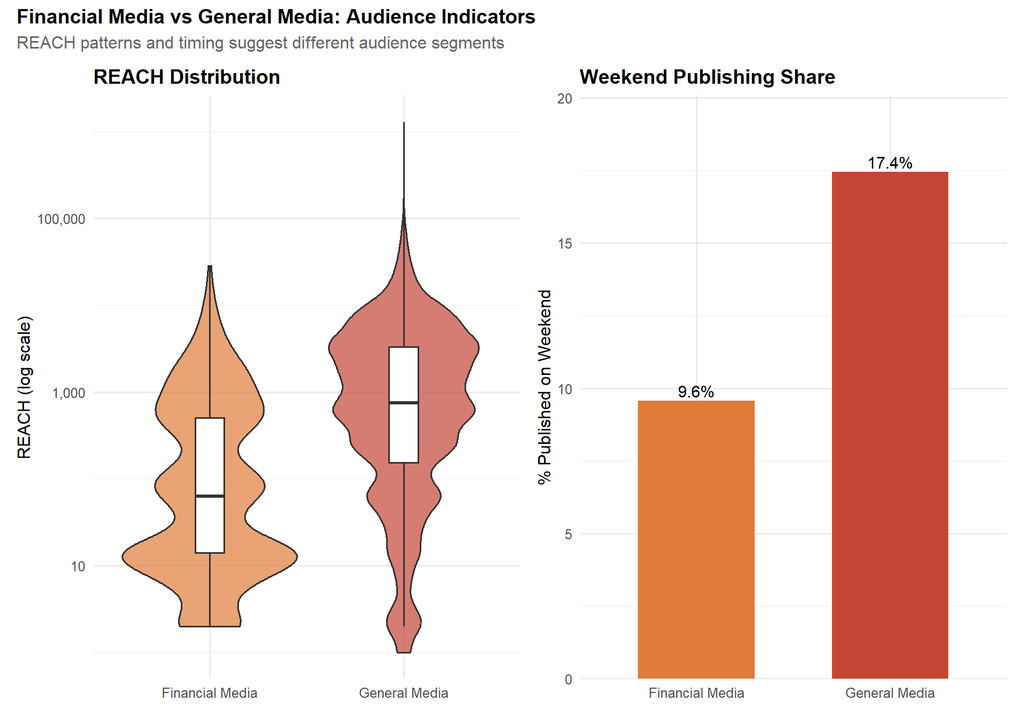

```r
media_comparison <- hnb[ACTOR_TYPE %in% c("Financial Media", "General Media")]

media_stats <- media_comparison[, .(
  Articles = .N,
  Total_REACH = sum(REACH, na.rm = TRUE),
  Mean_REACH = mean(REACH, na.rm = TRUE),
  Median_REACH = median(REACH, na.rm = TRUE),
  SD_REACH = sd(REACH, na.rm = TRUE),
  Weekend_Share = sum(is_weekend) / .N * 100,
  Sources = uniqueN(FROM)
), by = ACTOR_TYPE]

# Visualization
p1 <- ggplot(media_comparison, aes(x = ACTOR_TYPE, y = REACH, fill = ACTOR_TYPE)) +
  geom_violin(alpha = 0.7) +
  geom_boxplot(width = 0.15, fill = "white", outlier.shape = NA) +
  scale_y_log10(labels = comma) +
  scale_fill_manual(values = actor_colors) +
  labs(
    title = "REACH Distribution",
    x = NULL,
    y = "REACH (log scale)"
  ) +
  theme(legend.position = "none")

p2 <- ggplot(media_stats, aes(x = ACTOR_TYPE, y = Weekend_Share, fill = ACTOR_TYPE)) +
  geom_col(width = 0.6) +
  geom_text(aes(label = sprintf("%.1f%%", Weekend_Share)), vjust = -0.3, size = 4) +
  scale_fill_manual(values = actor_colors) +
  scale_y_continuous(expand = expansion(mult = c(0, 0.15))) +
  labs(
    title = "Weekend Publishing Share",
    x = NULL,
    y = "% Published on Weekend"
  ) +
  theme(legend.position = "none")

p1 + p2 + plot_annotation(
  title = "Financial Media vs General Media: Audience Indicators",
  subtitle = "REACH patterns and timing suggest different audience segments"
)
```

# 3 Analysis 10.2: Temporal Patterns as Audience Proxies

## 3.1 Weekday vs Weekend Publication

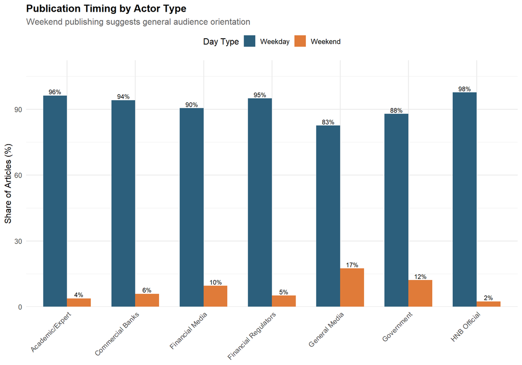

```r
day_type_actor <- hnb[ACTOR_TYPE != "Other", .(
  Articles = .N,
  Total_REACH = sum(REACH, na.rm = TRUE),
  Mean_REACH = mean(REACH, na.rm = TRUE)
), by = .(ACTOR_TYPE, day_type)]

day_type_actor[, Article_Share := Articles / sum(Articles) * 100, by = ACTOR_TYPE]

ggplot(day_type_actor, aes(x = ACTOR_TYPE, y = Article_Share, fill = day_type)) +
  geom_col(position = "dodge", width = 0.7) +
  geom_text(aes(label = sprintf("%.0f%%", Article_Share)),
            position = position_dodge(width = 0.7), vjust = -0.3, size = 3) +
  scale_fill_manual(values = day_colors) +
  scale_y_continuous(expand = expansion(mult = c(0, 0.15))) +
  labs(
    title = "Publication Timing by Actor Type",
    subtitle = "Weekend publishing suggests general audience orientation",
    x = NULL,
    y = "Share of Articles (%)",
    fill = "Day Type"
  ) +
  theme(axis.text.x = element_text(angle = 45, hjust = 1), legend.position = "top")
```

## 3.2 Weekend Publishing Index

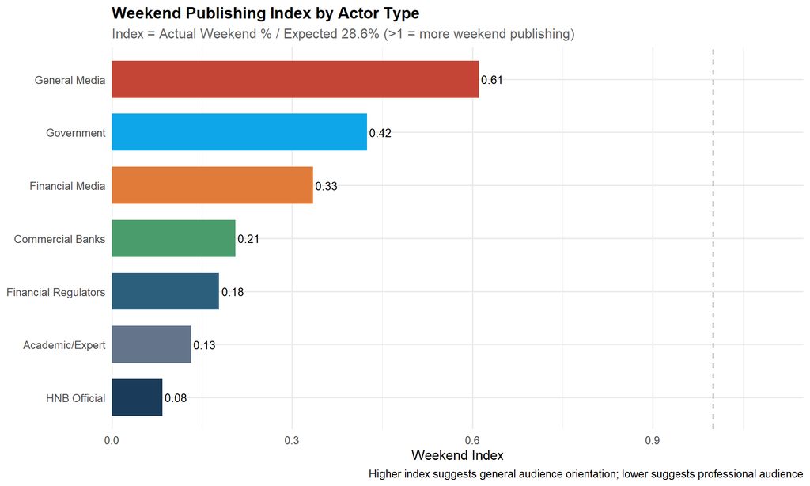

```r
# Calculate weekend index (weekend share / expected share if random)
# Expected weekend share = 2/7 = 28.6%
expected_weekend <- 2/7 * 100

weekend_index <- hnb[ACTOR_TYPE != "Other", .(
  Weekend_Share = sum(is_weekend) / .N * 100,
  Articles = .N
), by = ACTOR_TYPE]

weekend_index[, Weekend_Index := Weekend_Share / expected_weekend]

ggplot(weekend_index, aes(x = reorder(ACTOR_TYPE, Weekend_Index), y = Weekend_Index, fill = ACTOR_TYPE)) +
  geom_col(width = 0.7) +
  geom_hline(yintercept = 1, linetype = "dashed", color = "gray50") +
  geom_text(aes(label = sprintf("%.2f", Weekend_Index)), hjust = -0.1, size = 3.5) +
  coord_flip() +
  scale_fill_manual(values = actor_colors) +
  scale_y_continuous(expand = expansion(mult = c(0, 0.15))) +
  labs(
    title = "Weekend Publishing Index by Actor Type",
    subtitle = "Index = Actual Weekend % / Expected 28.6% (>1 = more weekend publishing)",
    x = NULL,
    y = "Weekend Index",
    caption = "Higher index suggests general audience orientation; lower suggests professional audience"
  ) +
  theme(legend.position = "none")
```

## 3.3 Hourly Patterns (if available)

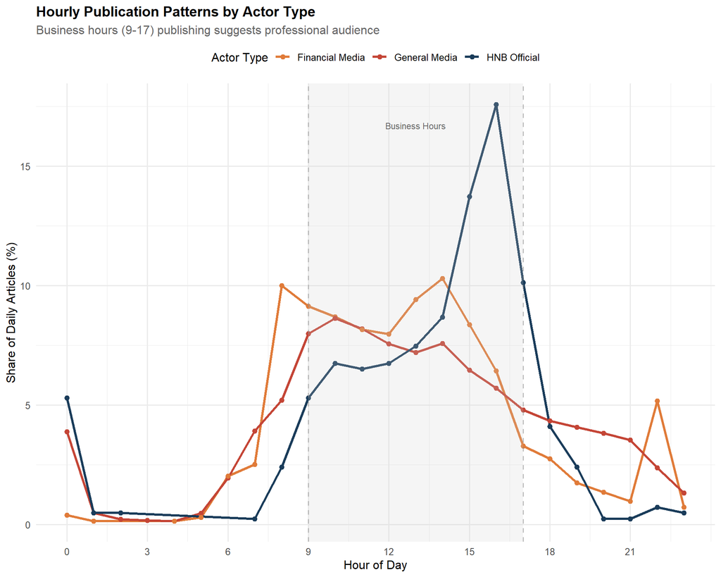

```r
if (has_time && sum(!is.na(hnb$hour)) > 500) {
  hourly_actor <- hnb[!is.na(hour) & ACTOR_TYPE %in% c("HNB Official", "Financial Media", "General Media"), .(
    Articles = .N
  ), by = .(ACTOR_TYPE, hour)]

  hourly_actor[, Share := Articles / sum(Articles) * 100, by = ACTOR_TYPE]

  ggplot(hourly_actor, aes(x = hour, y = Share, color = ACTOR_TYPE)) +
    geom_line(linewidth = 1.2) +
    geom_point(size = 2) +
    geom_vline(xintercept = c(9, 17), linetype = "dashed", color = "gray50", alpha = 0.5) +
    annotate("rect", xmin = 9, xmax = 17, ymin = -Inf, ymax = Inf,
             fill = "gray80", alpha = 0.2) +
    annotate("text", x = 13, y = max(hourly_actor$Share) * 0.95,
             label = "Business Hours", color = "gray40", size = 3) +
    scale_x_continuous(breaks = seq(0, 23, 3)) +
    scale_color_manual(values = actor_colors) +
    labs(
      title = "Hourly Publication Patterns by Actor Type",
      subtitle = "Business hours (9-17) publishing suggests professional audience",
      x = "Hour of Day",
      y = "Share of Daily Articles (%)",
      color = "Actor Type"
    ) +
    theme(legend.position = "top")
} else {
  cat("Insufficient hourly data for analysis.\n")
}
```

## 3.4 Business Hours Index

```r
if (has_time && sum(!is.na(hnb$hour)) > 500) {
  # Define business hours as 9-17
  hnb[, is_business_hours := hour >= 9 & hour <= 17]

  business_index <- hnb[!is.na(hour) & ACTOR_TYPE != "Other", .(
    Business_Hours_Share = sum(is_business_hours, na.rm = TRUE) / .N * 100,
    Articles = .N
  ), by = ACTOR_TYPE]

  # Expected if random = 9/24 = 37.5%
  expected_business <- 9/24 * 100
  business_index[, Business_Index := Business_Hours_Share / expected_business]

  business_index[order(-Business_Index)] %>%
    mutate(
      Articles = format(Articles, big.mark = ","),
      Business_Hours_Share = sprintf("%.1f%%", Business_Hours_Share),
      Business_Index = sprintf("%.2f", Business_Index),
      Audience_Signal = ifelse(as.numeric(Business_Index) > 1.2, "Professional",
                               ifelse(as.numeric(Business_Index) < 0.8, "General", "Mixed"))
    ) %>%
    kable(col.names = c("Actor Type", "Articles", "Business Hours %",
                        "Business Index", "Audience Signal")) %>%
    kable_styling(bootstrap_options = c("striped", "hover"), full_width = FALSE)
}
```

| Actor Type | Articles | Business Hours % | Business Index | Audience Signal |
| --- | --- | --- | --- | --- |
| HNB Official | 82.9% | 415 | 2.21 | Professional |
| Academic/Expert | 75.5% | 53 | 2.01 | Professional |
| Commercial Banks | 72.5% | 51 | 1.93 | Professional |
| Government | 72.0% | 371 | 1.92 | Professional |
| Financial Media | 71.8% | 2,069 | 1.91 | Professional |
| Financial Regulators | 68.4% | 98 | 1.82 | Professional |
| General Media | 64.1% | 13,319 | 1.71 | Professional |

# 4 Analysis 10.3: REACH Pattern Clustering

## 4.1 Source Clustering by REACH Characteristics

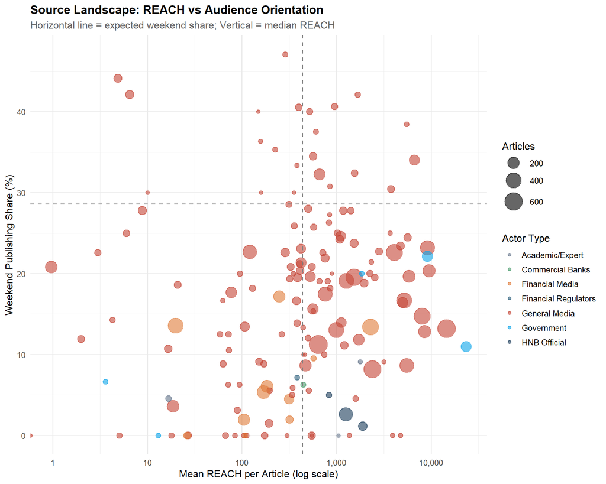

```r
# Calculate source-level metrics for clustering
source_metrics <- hnb[, .(
  Articles = .N,
  Total_REACH = sum(REACH, na.rm = TRUE),
  Mean_REACH = mean(REACH, na.rm = TRUE),
  Median_REACH = median(REACH, na.rm = TRUE),
  SD_REACH = sd(REACH, na.rm = TRUE),
  Weekend_Share = sum(is_weekend) / .N * 100,
  ACTOR_TYPE = first(ACTOR_TYPE)
), by = FROM][Articles >= 10]  # Minimum 10 articles for stability

source_metrics[, `:=`(
  REACH_CV = SD_REACH / Mean_REACH,  # Coefficient of variation
  REACH_Category = fcase(
    Mean_REACH > quantile(Mean_REACH, 0.75, na.rm = TRUE), "High REACH",
    Mean_REACH > quantile(Mean_REACH, 0.25, na.rm = TRUE), "Medium REACH",
    default = "Low REACH"
  )
)]

# Visualize source landscape
ggplot(source_metrics[ACTOR_TYPE != "Other"],
       aes(x = Mean_REACH, y = Weekend_Share, color = ACTOR_TYPE, size = Articles)) +
  geom_point(alpha = 0.6) +
  geom_hline(yintercept = 28.6, linetype = "dashed", color = "gray50") +
  geom_vline(xintercept = median(source_metrics$Mean_REACH, na.rm = TRUE),
             linetype = "dashed", color = "gray50") +
  scale_x_log10(labels = comma) +
  scale_size_continuous(range = c(2, 10)) +
  scale_color_manual(values = actor_colors) +
  annotate("text", x = min(source_metrics$Mean_REACH) * 1.5, y = 45,
           label = "General Audience\nLow REACH", hjust = 0, size = 3, color = "gray40") +
  annotate("text", x = max(source_metrics$Mean_REACH) * 0.3, y = 45,
           label = "General Audience\nHigh REACH", hjust = 0, size = 3, color = "gray40") +
  annotate("text", x = min(source_metrics$Mean_REACH) * 1.5, y = 10,
           label = "Professional\nLow REACH", hjust = 0, size = 3, color = "gray40") +
  annotate("text", x = max(source_metrics$Mean_REACH) * 0.3, y = 10,
           label = "Professional\nHigh REACH", hjust = 0, size = 3, color = "gray40") +
  labs(
    title = "Source Landscape: REACH vs Audience Orientation",
    subtitle = "Horizontal line = expected weekend share; Vertical = median REACH",
    x = "Mean REACH per Article (log scale)",
    y = "Weekend Publishing Share (%)",
    color = "Actor Type",
    size = "Articles"
  ) +
  theme(legend.position = "right")
```

## 4.2 Audience Segment Assignment

```r
# Assign audience segments based on indicators
source_metrics[, Audience_Segment := fcase(
  Weekend_Share < 20 & Mean_REACH > median(Mean_REACH, na.rm = TRUE), "Professional/Expert",
  Weekend_Share > 35, "General Public",
  Mean_REACH > quantile(Mean_REACH, 0.75, na.rm = TRUE), "Informed Public",
  default = "Mixed"
)]

segment_summary <- source_metrics[, .(
  Sources = .N,
  Articles = sum(Articles),
  Total_REACH = sum(Total_REACH),
  Mean_Source_REACH = mean(Mean_REACH, na.rm = TRUE),
  Mean_Weekend_Share = mean(Weekend_Share, na.rm = TRUE)
), by = Audience_Segment][order(-Total_REACH)]

segment_summary[, REACH_Share := Total_REACH / sum(Total_REACH) * 100]

segment_summary %>%
  mutate(
    Sources = format(Sources, big.mark = ","),
    Articles = format(Articles, big.mark = ","),
    Total_REACH = format(Total_REACH, big.mark = ","),
    REACH_Share = sprintf("%.1f%%", REACH_Share),
    Mean_Source_REACH = format(round(Mean_Source_REACH, 0), big.mark = ","),
    Mean_Weekend_Share = sprintf("%.1f%%", Mean_Weekend_Share)
  ) %>%
  kable(col.names = c("Audience Segment", "Sources", "Articles", "Total REACH",
                      "REACH Share", "Mean REACH", "Weekend %")) %>%
  kable_styling(bootstrap_options = c("striped", "hover"), full_width = FALSE)
```

| Audience Segment | Sources | Articles | Total REACH | REACH Share | Mean REACH | Weekend % |
| --- | --- | --- | --- | --- | --- | --- |
| Professional/Expert | 55 | 8,207 | 32,565,482 | 3,482 | 10.4% | 68.8% |
| Informed Public | 19 | 2,490 | 12,915,439 | 4,173 | 25.0% | 27.3% |
| Mixed | 112 | 6,311 | 1,612,962 | 278 | 14.9% | 3.4% |
| General Public | 16 | 424 | 251,611 | 1,011 | 40.9% | 0.5% |

## 4.3 Segment Visualization

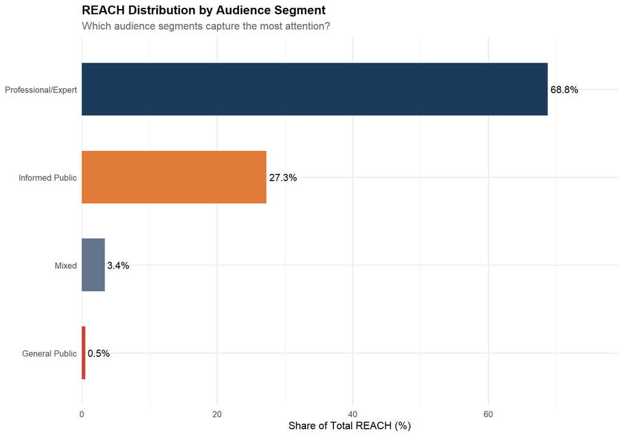

```r
segment_reach <- segment_summary %>%
  select(Audience_Segment, REACH_Share) %>%
  mutate(REACH_Share = as.numeric(gsub("%", "", REACH_Share)))

ggplot(segment_reach, aes(x = reorder(Audience_Segment, REACH_Share),
                          y = REACH_Share, fill = Audience_Segment)) +
  geom_col(width = 0.6) +
  geom_text(aes(label = sprintf("%.1f%%", REACH_Share)), hjust = -0.1, size = 4) +
  coord_flip() +
  scale_fill_manual(values = audience_colors) +
  scale_y_continuous(expand = expansion(mult = c(0, 0.15))) +
  labs(
    title = "REACH Distribution by Audience Segment",
    subtitle = "Which audience segments capture the most attention?",
    x = NULL,
    y = "Share of Total REACH (%)"
  ) +
  theme(legend.position = "none")
```

# 5 Analysis 10.4: Actor Type to Audience Mapping

## 5.1 Actor-Audience Matrix

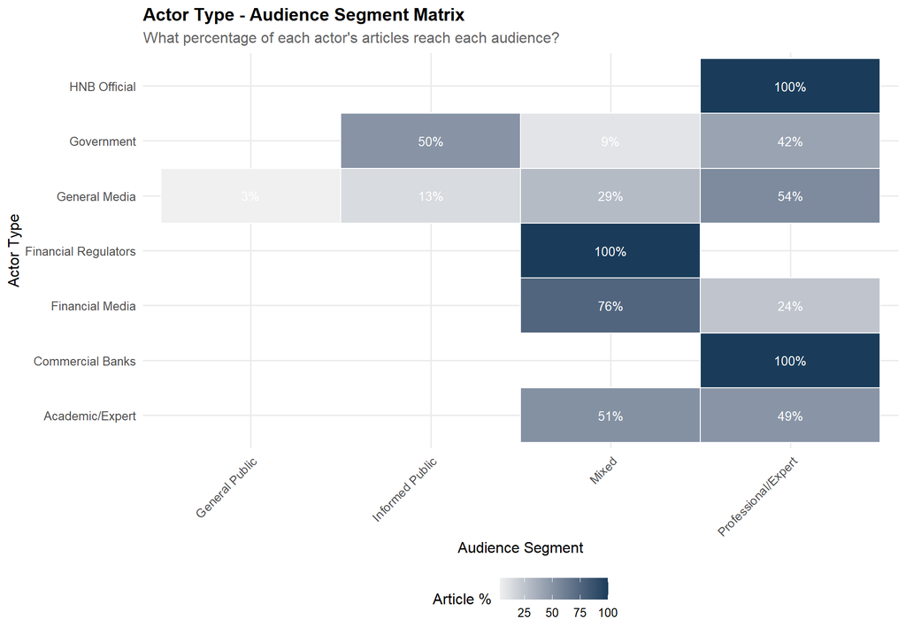

```r
actor_segment <- merge(
  source_metrics[, .(Sources = .N, Articles = sum(Articles), REACH = sum(Total_REACH)),
                 by = .(ACTOR_TYPE, Audience_Segment)],
  source_metrics[, .(Total_Sources = .N, Total_Articles = sum(Articles)), by = ACTOR_TYPE],
  by = "ACTOR_TYPE"
)

actor_segment[, `:=`(
  Source_Share = Sources / Total_Sources * 100,
  Article_Share = Articles / Total_Articles * 100
)]

# Heatmap
ggplot(actor_segment[ACTOR_TYPE != "Other"],
       aes(x = Audience_Segment, y = ACTOR_TYPE, fill = Article_Share)) +
  geom_tile(color = "white", linewidth = 0.5) +
  geom_text(aes(label = sprintf("%.0f%%", Article_Share)), color = "white", size = 3.5) +
  scale_fill_gradient(low = "#f0f0f0", high = "#1a3c5a") +
  labs(
    title = "Actor Type - Audience Segment Matrix",
    subtitle = "What percentage of each actor's articles reach each audience?",
    x = "Audience Segment",
    y = "Actor Type",
    fill = "Article %"
  ) +
  theme(axis.text.x = element_text(angle = 45, hjust = 1))
```

## 5.2 Primary Audience by Actor Type

```r
primary_audience <- actor_segment[, .SD[which.max(Article_Share)], by = ACTOR_TYPE]

primary_audience[ACTOR_TYPE != "Other"][order(-Article_Share)] %>%
  mutate(
    Sources = format(Sources, big.mark = ","),
    Articles = format(Articles, big.mark = ","),
    Article_Share = sprintf("%.1f%%", Article_Share)
  ) %>%
  select(ACTOR_TYPE, Audience_Segment, Sources, Articles, Article_Share) %>%
  kable(col.names = c("Actor Type", "Primary Audience", "Sources", "Articles", "Share")) %>%
  kable_styling(bootstrap_options = c("striped", "hover"), full_width = FALSE)
```

| Actor Type | Primary Audience | Sources | Articles | Share |
| --- | --- | --- | --- | --- |
| Commercial Banks | Professional/Expert | 1 | 16 | 100.0% |
| Financial Regulators | Mixed | 1 | 14 | 100.0% |
| HNB Official | Professional/Expert | 3 | 415 | 100.0% |
| Financial Media | Mixed | 9 | 1,539 | 75.5% |
| General Media | Professional/Expert | 38 | 6,721 | 54.4% |
| Academic/Expert | Mixed | 1 | 22 | 51.2% |
| Government | Informed Public | 2 | 173 | 49.6% |

# 6 Analysis 10.5: HNB Communication Reach by Audience

## 6.1 HNB Official Audience Penetration

```r
# How does HNB Official reach different audience segments?
hnb_segment <- source_metrics[ACTOR_TYPE == "HNB Official"]

if (nrow(hnb_segment) > 0) {
  hnb_audience <- hnb_segment[, .(
    Sources = .N,
    Articles = sum(Articles),
    Total_REACH = sum(Total_REACH)
  ), by = Audience_Segment]

  hnb_audience[, REACH_Share := Total_REACH / sum(Total_REACH) * 100]

  cat("HNB Official Audience Penetration\n")
  cat("==================================\n")
  print(hnb_audience)
} else {
  cat("Insufficient HNB Official source data for segment analysis.\n")
}
```

```
HNB Official Audience Penetration
==================================
      Audience_Segment Sources Articles Total_REACH REACH_Share
                <char>   <int>    <int>       <num>       <num>
1: Professional/Expert       3      415      567340         100
```

## 6.2 Audience Segment Comparison: HNB vs Media

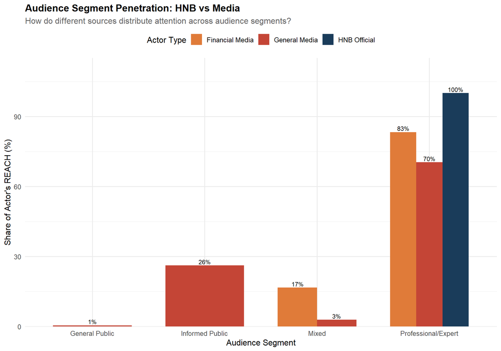

```r
# Compare how HNB Official vs Media reach different segments
hnb_media_segment <- source_metrics[ACTOR_TYPE %in% c("HNB Official", "Financial Media", "General Media"), .(
  Articles = sum(Articles),
  Total_REACH = sum(Total_REACH)
), by = .(ACTOR_TYPE, Audience_Segment)]

hnb_media_segment[, REACH_Share := Total_REACH / sum(Total_REACH) * 100, by = ACTOR_TYPE]

ggplot(hnb_media_segment, aes(x = Audience_Segment, y = REACH_Share, fill = ACTOR_TYPE)) +
  geom_col(position = "dodge", width = 0.7) +
  geom_text(aes(label = sprintf("%.0f%%", REACH_Share)),
            position = position_dodge(width = 0.7), vjust = -0.3, size = 3) +
  scale_fill_manual(values = actor_colors) +
  scale_y_continuous(expand = expansion(mult = c(0, 0.15))) +
  labs(
    title = "Audience Segment Penetration: HNB vs Media",
    subtitle = "How do different sources distribute attention across audience segments?",
    x = "Audience Segment",
    y = "Share of Actor's REACH (%)",
    fill = "Actor Type"
  ) +
  theme(legend.position = "top")
```

# 7 Analysis 10.6: Layered Communication Opportunities

## 7.1 Communication Channel Matrix

Based on audience segmentation, we identify optimal channels for different communication objectives:

```r
# Build channel recommendation matrix
channel_matrix <- data.table(
  Audience = c("Professional/Expert", "Professional/Expert",
               "Informed Public", "Informed Public",
               "General Public", "General Public"),
  Objective = c("Technical Detail", "Market Guidance",
                "Policy Explanation", "Economic Context",
                "Awareness Building", "Trust Building"),
  Recommended_Channel = c("HNB Official, Financial Media", "Financial Media, HNB Official",
                          "Quality General Media", "Financial Media",
                          "Mass General Media", "All Channels"),
  Timing = c("Business hours, weekday", "Market hours",
             "Morning, weekday", "Any",
             "Evening, weekend", "Consistent"),
  Complexity = c("High", "Medium-High",
                 "Medium", "Medium",
                 "Low", "Low")
)

channel_matrix %>%
  kable(col.names = c("Target Audience", "Communication Objective",
                      "Recommended Channel", "Optimal Timing", "Complexity")) %>%
  kable_styling(bootstrap_options = c("striped", "hover"), full_width = FALSE)
```

| Target Audience | Communication Objective | Recommended Channel | Optimal Timing | Complexity |
| --- | --- | --- | --- | --- |
| Professional/Expert | Technical Detail | HNB Official, Financial Media | Business hours, weekday | High |
| Professional/Expert | Market Guidance | Financial Media, HNB Official | Market hours | Medium-High |
| Informed Public | Policy Explanation | Quality General Media | Morning, weekday | Medium |
| Informed Public | Economic Context | Financial Media | Any | Medium |
| General Public | Awareness Building | Mass General Media | Evening, weekend | Low |
| General Public | Trust Building | All Channels | Consistent | Low |

## 7.2 Audience Reach Gap Analysis

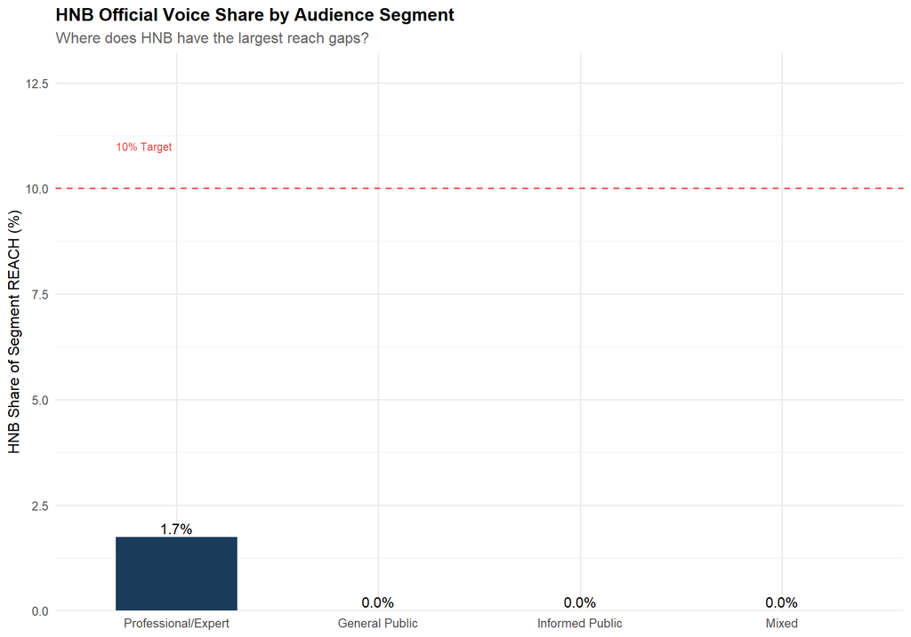

```r
# Calculate HNB's reach efficiency by segment
segment_totals <- source_metrics[, .(
  Segment_REACH = sum(Total_REACH)
), by = Audience_Segment]

hnb_segment_reach <- source_metrics[ACTOR_TYPE == "HNB Official", .(
  HNB_REACH = sum(Total_REACH)
), by = Audience_Segment]

if (nrow(hnb_segment_reach) > 0) {
  reach_gap <- merge(segment_totals, hnb_segment_reach, by = "Audience_Segment", all.x = TRUE)
  reach_gap[is.na(HNB_REACH), HNB_REACH := 0]
  reach_gap[, `:=`(
    HNB_Share = HNB_REACH / Segment_REACH * 100,
    Gap_to_10pct = 10 - (HNB_REACH / Segment_REACH * 100)  # Gap to 10% target
  )]

  ggplot(reach_gap, aes(x = reorder(Audience_Segment, -HNB_Share), y = HNB_Share,
                        fill = Audience_Segment)) +
    geom_col(width = 0.6) +
    geom_hline(yintercept = 10, linetype = "dashed", color = "#ef4444") +
    geom_text(aes(label = sprintf("%.1f%%", HNB_Share)), vjust = -0.3, size = 4) +
    annotate("text", x = 0.7, y = 11, label = "10% Target", hjust = 0, color = "#ef4444", size = 3) +
    scale_fill_manual(values = audience_colors) +
    scale_y_continuous(expand = expansion(mult = c(0, 0.2))) +
    labs(
      title = "HNB Official Voice Share by Audience Segment",
      subtitle = "Where does HNB have the largest reach gaps?",
      x = NULL,
      y = "HNB Share of Segment REACH (%)"
    ) +
    theme(legend.position = "none")
}
```

# 8 Analysis 10.7: Top Sources by Audience Segment

## 8.1 Leading Sources per Segment

```r
# Top 5 sources by REACH in each segment
top_by_segment <- source_metrics[, {
  .SD[order(-Total_REACH)][1:min(5, .N)]
}, by = Audience_Segment]

top_by_segment %>%
  mutate(
    Articles = format(Articles, big.mark = ","),
    Total_REACH = format(Total_REACH, big.mark = ","),
    Mean_REACH = format(round(Mean_REACH, 0), big.mark = ","),
    Weekend_Share = sprintf("%.0f%%", Weekend_Share)
  ) %>%
  select(Audience_Segment, FROM, ACTOR_TYPE, Articles, Total_REACH, Weekend_Share) %>%
  kable(col.names = c("Segment", "Source", "Actor Type", "Articles", "REACH", "Weekend %")) %>%
  kable_styling(bootstrap_options = c("striped", "hover"), full_width = FALSE) %>%
  scroll_box(height = "500px")
```

| Segment | Source | Actor Type | Articles | REACH | Weekend % |
| --- | --- | --- | --- | --- | --- |
| Mixed | dalmacijadanas.hr | General Media | 130 | 144,000 | 25% |
| Mixed | 7dnevno.hr | General Media | 183 | 121,154 | 32% |
| Mixed | kamenjar.com | Other | 97 | 99,072 | 21% |
| Mixed | dalmacijanews.hr | General Media | 66 | 71,118 | 24% |
| Mixed | 034portal.hr | General Media | 54 | 63,387 | 28% |
| Professional/Expert | index.hr | General Media | 622 | 9,042,168 | 13% |
| Professional/Expert | jutarnji.hr | General Media | 509 | 4,083,489 | 15% |
| Professional/Expert | gov.hr | Government | 146 | 3,433,941 | 11% |
| Professional/Expert | 24sata.hr | General Media | 249 | 2,130,930 | 13% |
| Professional/Expert | vecernji.hr | General Media | 395 | 1,994,910 | 17% |
| General Public | Večernji list | General Media | 13 | 71,560 | 38% |
| General Public | logicno.com | Other | 11 | 54,753 | 36% |
| General Public | evarazdin.hr | General Media | 19 | 31,797 | 42% |
| General Public | zagorje-international.hr | General Media | 32 | 30,621 | 41% |
| General Public | novosti.hr | General Media | 35 | 18,160 | 40% |
| Informed Public | dnevno.hr | General Media | 362 | 3,311,931 | 23% |
| Informed Public | telegram.hr | General Media | 241 | 2,296,275 | 20% |
| Informed Public | slobodnadalmacija.hr | General Media | 491 | 2,000,454 | 23% |
| Informed Public | zagorje.com | Other | 641 | 1,549,461 | 24% |
| Informed Public | dalmatinskiportal.hr | Government | 158 | 1,442,913 | 22% |

## 8.2 Strategic Partnership Candidates

```r
# Identify high-REACH sources in underserved segments for HNB
partnership_candidates <- source_metrics[
  ACTOR_TYPE %in% c("Financial Media", "General Media") &
  Mean_REACH > quantile(Mean_REACH, 0.7, na.rm = TRUE)
][order(Audience_Segment, -Total_REACH)]

# Add strategic value score
partnership_candidates[, Strategic_Value := fcase(
  Audience_Segment == "General Public" & Mean_REACH > median(Mean_REACH), "High",
  Audience_Segment == "Informed Public", "Medium-High",
  Audience_Segment == "Professional/Expert", "Medium",
  default = "Standard"
)]

partnership_candidates[1:min(15, nrow(partnership_candidates))] %>%
  mutate(
    Articles = format(Articles, big.mark = ","),
    Total_REACH = format(Total_REACH, big.mark = ","),
    Mean_REACH = format(round(Mean_REACH, 0), big.mark = ","),
    Weekend_Share = sprintf("%.0f%%", Weekend_Share)
  ) %>%
  select(FROM, ACTOR_TYPE, Audience_Segment, Articles, Mean_REACH, Strategic_Value) %>%
  kable(col.names = c("Source", "Actor Type", "Audience", "Articles",
                      "Mean REACH", "Strategic Value"),
        caption = "Top Media Partnership Candidates for Audience Expansion") %>%
  kable_styling(bootstrap_options = c("striped", "hover"), full_width = FALSE)
```

Top Media Partnership Candidates for Audience Expansion

| Source | Actor Type | Audience | Articles | Mean REACH | Strategic Value |
| --- | --- | --- | --- | --- | --- |
| Večernji list | General Media | General Public | 13 | 5,505 | High |
| evarazdin.hr | General Media | General Public | 19 | 1,674 | Standard |
| zagorje-international.hr | General Media | General Public | 32 | 957 | Standard |
| dnevno.hr | General Media | Informed Public | 362 | 9,149 | Medium-High |
| telegram.hr | General Media | Informed Public | 241 | 9,528 | Medium-High |
| slobodnadalmacija.hr | General Media | Informed Public | 491 | 4,083 | Medium-High |
| priznajem.hr | General Media | Informed Public | 144 | 6,690 | Medium-High |
| net.hr | General Media | Informed Public | 64 | 4,713 | Medium-High |
| teleskop.hr | General Media | Informed Public | 49 | 5,646 | Medium-High |
| maxportal.hr | General Media | Informed Public | 46 | 3,777 | Medium-High |
| mirovina.hr | General Media | Informed Public | 44 | 2,823 | Medium-High |
| zagreb.info | General Media | Informed Public | 80 | 1,533 | Medium-High |
| danica.hr | General Media | Informed Public | 35 | 2,251 | Medium-High |
| medjimurski.hr | General Media | Informed Public | 37 | 1,550 | Medium-High |
| mnovine.hr | General Media | Informed Public | 36 | 1,410 | Medium-High |

# 9 Summary and Key Findings

## 9.1 Audience Segmentation Summary

```r
# Calculate key metrics
fin_media_weekend <- actor_profiles[ACTOR_TYPE == "Financial Media", Weekend_Share]
gen_media_weekend <- actor_profiles[ACTOR_TYPE == "General Media", Weekend_Share]
hnb_weekend <- actor_profiles[ACTOR_TYPE == "HNB Official", Weekend_Share]

professional_reach <- segment_summary[Audience_Segment == "Professional/Expert", REACH_Share]
general_reach <- segment_summary[Audience_Segment == "General Public", REACH_Share]

tibble(
  Finding = c(
    "Audience segments identified",
    "Professional/Expert REACH share",
    "General Public REACH share",
    "Financial Media weekend share",
    "General Media weekend share",
    "HNB Official weekend share",
    "HNB primary audience segment",
    "Largest HNB reach gap",
    "Top partnership candidate"
  ),
  Value = c(
    paste(unique(source_metrics$Audience_Segment), collapse = ", "),
    sprintf("%.1f%%", as.numeric(gsub("%", "", professional_reach))),
    sprintf("%.1f%%", as.numeric(gsub("%", "", general_reach))),
    sprintf("%.1f%%", fin_media_weekend),
    sprintf("%.1f%%", gen_media_weekend),
    sprintf("%.1f%%", hnb_weekend),
    if(nrow(hnb_segment) > 0) primary_audience[ACTOR_TYPE == "HNB Official", Audience_Segment] else "N/A",
    if(exists("reach_gap")) reach_gap[which.max(Gap_to_10pct), Audience_Segment] else "N/A",
    if(nrow(partnership_candidates) > 0) partnership_candidates$FROM[1] else "N/A"
  )
) %>%
  kable(col.names = c("Finding", "Value")) %>%
  kable_styling(bootstrap_options = c("striped", "hover"), full_width = FALSE)
```

| Finding | Value |
| --- | --- |
| Audience segments identified | Mixed, Professional/Expert, General Public, Informed Public |
| Professional/Expert REACH share | 68.8% |
| General Public REACH share | 0.5% |
| Financial Media weekend share | 9.6% |
| General Media weekend share | 17.4% |
| HNB Official weekend share | 2.4% |
| HNB primary audience segment | Professional/Expert |
| Largest HNB reach gap | General Public |
| Top partnership candidate | Večernji list |

## 9.2 Implications for HNB Communication Strategy

**1. Audience Differentiation**

**2. HNB Current Position**

HNB Official communication currently reaches primarily the Professional/Expert segment, with 2.4% weekend publishing share suggesting professional-oriented timing.

**3. Layered Communication Recommendation**

Following ECB best practices:

[output not shown]

**4. Strategic Partnerships**

To expand General Public reach, prioritize relationships with high-REACH sources that have strong weekend publishing patterns and general audience orientation.

**5. Timing Optimization**

Consider publishing simplified summaries during evening hours and weekends to capture General Public attention, while maintaining business-hours releases for market-oriented content.

# 10 Appendix: Methodological Notes

## 10.1 Audience Segment Classification

Sources are classified into audience segments based on:

1. **Weekend Publishing Share**
   - <20%: Professional orientation
   - 20-35%: Mixed
   - > 35%: General public orientation
2. **Mean REACH per Article**
   - Above median: Higher audience penetration
   - Below median: Niche audience
3. **Combined Classification**
   - Professional/Expert: Low weekend + High REACH
   - Informed Public: High REACH sources not fitting other categories
   - General Public: High weekend share
   - Mixed: All others

## 10.2 Weekend Index Calculation

$$\text{Weekend Index} = \frac{\text{Actual Weekend Share}}{28.6\%}$$

Where 28.6% = 2/7 is the expected weekend share if publishing were random.

## 10.3 Business Hours Index

$$\text{Business Index} = \frac{\text{Business Hours Share}}{37.5\%}$$

Where 37.5% = 9/24 is the expected business hours share if publishing were random.

## 10.4 Limitations

1. Audience segmentation is inferred from source characteristics, not direct audience data
2. REACH measures potential exposure, not confirmed audience demographics
3. Weekend publishing may reflect editorial schedules rather than audience targeting
4. Time-of-day patterns depend on TIME field availability